# Assignment 3: Model comparison

Katalin Kovacs

In this lab assignment you are going to work with (simulated) data related to perioperative pain and its psychological and hormonal predictors. In the assignment you will assess the added benefit of including some psychological and hormonal predictors to the already established demographic predictors of pain.

In this assignment you will set up a hierarchical regression model to predict postoperative pain after wisdom tooth surgery.

# Research problem

The amount of pain experienced around and after surgeries are highly variable between and within individuals. In order to improve surgical pain management regimens we need to understand what influences pain around surgical procedures and predict the amount of pain an individual will experience.

Your first study in this area is related to assessing the influence of trait and state psychological measures on pain, and to see whether taking into account these variables can improve our understanding of postoperative pain.

# Procedures and measures

Use the data file called ‘assignment_3_dataset’, from the ‘data/’ folder.

You have collected data from 160 adults who were scheduled to undergo surgical extraction of the third mandibular molar (wisdom tooth surgery). Patients filled out a form in the waiting room before their surgery. The form contained questions about their sex, age, and weight, and psychological questionnaires assessing anxiety, pain catastrophizing, and mindfulness (see descriptions below). You also got blood samples and saliva samples from participants in the waiting room 5 minutes before their operations to determine the serum (a component of the blood) and salivary cortisol levels of participants. Participants were contacted 5 hours after the surgery to see how much pain they were experiencing. The **level of pain** at that moment was recorded using a numerical rating scale using a **scale of 0 to 10**, where 0 means “no pain” and 10 means “worst pain I can imagine”.

**The State Trait Anxiety Inventory:** T measures trait anxiety on a scale of 20 to 80, higher scores mean higher anxiety. Anxiety has been found in many studies to positively correlate with the level of pain experienced. This is **variable STAI_trait** in the dataset.

**The Pain Catastrophizing Scale** measures the extent of pain catastrophizing, which is characterized by a tendency to magnify the threat value of a pain stimulus and to feel helpless in the presence of pain, as well as by a relative inability to prevent or inhibit pain-related thoughts in anticipation of, during, or following a painful event. The total score on this scale ranges from 0 to 52, higher scores mean higher catastrophizing. Pain catastrophizing is one of the well-established predictors of clinical pain. This is **variable pain_cat** in the dataset.

**The Mindful Attention Awareness Scale (MAAS)** measures dispositional mindfulness, which may be described as a tendency to turn attention to present-moment experiences in an open, non-judgmental way. The MAAS total score ranges from 1 to 6 (an average of the item scores), with higher scores representing higher dispositional mindfulness. Trait mindfulness has been theorized to serve as a protective factor against pain, as the individual would be more objective about their pain experience and tend to associate less discomfort, despair, and hopelessness to the pain-related sensations. This is **variable mindfulness** in the dataset.

**Cortisol** is a stress hormone associated with acute and chronic stress. Cortisol levels are thought to be positively associated with pain experience. Cortisol can be **measured from both blood and the saliva**, although, serum cortisol is often regarded in medical research as more reliably related to stress (serum is a component of the blood plasma). These are **variables cortisol_serum**, and **cortisol_saliva** in the dataset.

# Research question

Previous studies and meta-analyses showed that age and sex are often predictors of pain (age is negatively associated with pain, while sex is a predictor more dependent on the type of the procedure). You would like to determine the extent to which taking into account psychological and hormonal variables aside from the already used demographic variables would improve our understanding of postoperative pain.

To answer this research question you will **need to compare two models** (with a hierarchical regression). The **simpler model** should contain **age and sex as predictors of pain**, while the **more complex model** should contain the **predictors: age, sex, STAI, pain catastrophizing, mindfulness, and cortisol measures**. Notice that the predictors used in the simpler model are a subset of the predictors used in more complex model. **You will have to do model comparison to assess whether substantial new information was gained about pain in the more complex model compared to the simpler model.**

# What to report

As usual, before you can interpret your model, you will need to run data and model diagnostics. First, check the variables included in the more complex model (age, sex, STAI, pain catastrophizing, mindfulness, and cortisol measures as predictors, and pain as an outcome) for **coding errors**, and the model itself for **influential outliers** (for example using Cook’s distance). Furthermore, check the final model to see if the **assumptions of linear regression hold true**, that is, **normality** (of the residuals), **linearity** (of the relationship), **homogeneity of variance** (also called homoscedasticity) and that there is no excess **multicollinearity** (“uncorrelated predictors” in Navarro’s words). If you find anything amiss during these checks, make the appropriate decision or correction and report your findings and actions in your report.

**Note:** If you do any changes, such as exclude cases, or exclude predictors from the model, you will have to re-run the above checks for your final data and model.

Report the results of the simpler model and the more complex model. For both models you should report the model test statistics (adj.R2, F, df, and p value). Also, report the statistics describing the coefficients of the predictors in a table format (unstandardized regression coefficients and 95% confidence intervals, standardized regression coefficients (B and Beta values), and p values).

Write up the regression equation of the more complex model in the form of 𝑌 = 𝑏0 + 𝑏1 ∗ X1 + 𝑏2 ∗ X2 +…+ bn * Xn, in which you use the actual regression coefficients of your models. (b0 stands for the intercept and b1, b2 … bn stand for the model coefficients for each of the predictors, and X1, X2, … Xn denote the predictors).

Compare the two models in terms of how much variance they explain of pain’s variability in the sample. Report Akaike information criterion (AIC) for both models and the F test statistic and p value of the likelihood ratio test comparing the two models.

# What to discuss

In your discussion of the findings, briefly interpret the results of the above analyses, and indicate whether you think that anything was gained by including the psychological and hormone measures in the model.

# Solution

## Read the data

Read the dataset used in this assignment. Pay attention to the extension of the datafile.

```r
data_pain <- readxl::read_xlsx("data/assignment_3_dataset.xlsx")
```

```r
glimpse(data_pain)
```

```
## Rows: 160
## Columns: 12
## $ ID               <chr> "ID_1", "ID_2", "ID_3", "ID_4", "ID_5", "ID_6", "ID_7…
## $ pain             <dbl> 5, 4, 5, 7, 4, 6, 4, 5, 4, 5, 6, 3, 4, 5, 7, 4, 4, 4,…
## $ sex              <chr> "female", "female", "female", "female", "male", "fema…
## $ age              <dbl> 38, 36, 51, 39, 48, 45, 45, 35, 39, 33, 46, 42, 36, 4…
## $ STAI_trait       <dbl> 39, 46, 49, 48, 36, 37, 34, 39, 31, 38, 37, 35, 37, 3…
## $ pain_cat         <dbl> 25, 31, 32, 41, 26, 28, 22, 32, 27, 36, 26, 29, 26, 4…
## $ cortisol_serum   <dbl> 4.67, 6.01, 5.18, 6.65, 2.95, 4.32, 5.32, 5.26, 3.36,…
## $ cortisol_saliva  <dbl> 4.78, 6.71, 4.75, 6.68, 3.20, 4.36, 5.19, 5.53, 3.30,…
## $ mindfulness      <dbl> 3.83, 2.82, 3.93, 1.90, 4.39, 3.01, 4.97, 2.95, 3.43,…
## $ weight           <dbl> 62.14, 97.13, 78.96, 78.50, 76.88, 47.22, 55.10, 68.2…
## $ IQ               <dbl> 99, 71, 97, 97, 129, 115, 74, 98, 93, 76, 81, 103, 10…
## $ household_income <dbl> 52505, 64993, 68598, 47822, 100580, 43960, 65548, 436…
```

```r
summary(data_pain)
```

```
##          ID           pain               sex           age
##  Length   :160   Min.   : 1.000   Length   :160   Min.   :24.00
##  N.unique :160   1st Qu.: 4.000   N.unique :  3   1st Qu.:38.00
##  N.blank  :  0   Median : 5.000   N.blank  :  0   Median :41.00
##  Min.nchar:  4   Mean   : 5.194   Min.nchar:  4   Mean   :40.74
##  Max.nchar:  6   3rd Qu.: 6.000   Max.nchar:  6   3rd Qu.:44.00
##                  Max.   :50.000                   Max.   :53.00
##    STAI_trait       pain_cat     cortisol_serum  cortisol_saliva
##  Min.   :26.00   Min.   :14.00   Min.   :2.700   Min.   :2.530
##  1st Qu.:37.00   1st Qu.:27.00   1st Qu.:4.268   1st Qu.:4.120
##  Median :40.00   Median :30.00   Median :4.995   Median :5.035
##  Mean   :40.09   Mean   :29.88   Mean   :4.941   Mean   :4.952
##  3rd Qu.:43.00   3rd Qu.:32.25   3rd Qu.:5.633   3rd Qu.:5.753
##  Max.   :52.00   Max.   :42.00   Max.   :7.110   Max.   :7.190
##   mindfulness        weight            IQ         household_income
##  Min.   :1.000   Min.   :33.80   Min.   : 52.00   Min.   :  5548
##  1st Qu.:2.595   1st Qu.:62.15   1st Qu.: 91.75   1st Qu.: 53489
##  Median :3.115   Median :68.77   Median :101.00   Median : 72149
##  Mean   :3.204   Mean   :68.57   Mean   :100.74   Mean   : 70426
##  3rd Qu.:3.830   3rd Qu.:74.65   3rd Qu.:109.00   3rd Qu.: 87734
##  Max.   :6.220   Max.   :97.13   Max.   :144.00   Max.   :139268
```

```r
count(data_pain, sex)
```

```
## # A tibble: 3 × 2
##   sex        n
##   <chr>  <int>
## 1 female    83
## 2 male      76
## 3 woman      1
```

## Data and model diagnostics

### Data diagnostics

#### Descriptives of the variables

Run an exploratory data analysis (EDA) to investigate the dataset.

```r
# Look at the structure of the data
glimpse(data_pain)
```

```
## Rows: 160
## Columns: 12
## $ ID               <chr> "ID_1", "ID_2", "ID_3", "ID_4", "ID_5", "ID_6", "ID_7…
## $ pain             <dbl> 5, 4, 5, 7, 4, 6, 4, 5, 4, 5, 6, 3, 4, 5, 7, 4, 4, 4,…
## $ sex              <chr> "female", "female", "female", "female", "male", "fema…
## $ age              <dbl> 38, 36, 51, 39, 48, 45, 45, 35, 39, 33, 46, 42, 36, 4…
## $ STAI_trait       <dbl> 39, 46, 49, 48, 36, 37, 34, 39, 31, 38, 37, 35, 37, 3…
## $ pain_cat         <dbl> 25, 31, 32, 41, 26, 28, 22, 32, 27, 36, 26, 29, 26, 4…
## $ cortisol_serum   <dbl> 4.67, 6.01, 5.18, 6.65, 2.95, 4.32, 5.32, 5.26, 3.36,…
## $ cortisol_saliva  <dbl> 4.78, 6.71, 4.75, 6.68, 3.20, 4.36, 5.19, 5.53, 3.30,…
## $ mindfulness      <dbl> 3.83, 2.82, 3.93, 1.90, 4.39, 3.01, 4.97, 2.95, 3.43,…
## $ weight           <dbl> 62.14, 97.13, 78.96, 78.50, 76.88, 47.22, 55.10, 68.2…
## $ IQ               <dbl> 99, 71, 97, 97, 129, 115, 74, 98, 93, 76, 81, 103, 10…
## $ household_income <dbl> 52505, 64993, 68598, 47822, 100580, 43960, 65548, 436…
```

```r
# Basic descriptives: min, max, mean, NA count
summary(data_pain)
```

```
##          ID           pain               sex           age
##  Length   :160   Min.   : 1.000   Length   :160   Min.   :24.00
##  N.unique :160   1st Qu.: 4.000   N.unique :  3   1st Qu.:38.00
##  N.blank  :  0   Median : 5.000   N.blank  :  0   Median :41.00
##  Min.nchar:  4   Mean   : 5.194   Min.nchar:  4   Mean   :40.74
##  Max.nchar:  6   3rd Qu.: 6.000   Max.nchar:  6   3rd Qu.:44.00
##                  Max.   :50.000                   Max.   :53.00
##    STAI_trait       pain_cat     cortisol_serum  cortisol_saliva
##  Min.   :26.00   Min.   :14.00   Min.   :2.700   Min.   :2.530
##  1st Qu.:37.00   1st Qu.:27.00   1st Qu.:4.268   1st Qu.:4.120
##  Median :40.00   Median :30.00   Median :4.995   Median :5.035
##  Mean   :40.09   Mean   :29.88   Mean   :4.941   Mean   :4.952
##  3rd Qu.:43.00   3rd Qu.:32.25   3rd Qu.:5.633   3rd Qu.:5.753
##  Max.   :52.00   Max.   :42.00   Max.   :7.110   Max.   :7.190
##   mindfulness        weight            IQ         household_income
##  Min.   :1.000   Min.   :33.80   Min.   : 52.00   Min.   :  5548
##  1st Qu.:2.595   1st Qu.:62.15   1st Qu.: 91.75   1st Qu.: 53489
##  Median :3.115   Median :68.77   Median :101.00   Median : 72149
##  Mean   :3.204   Mean   :68.57   Mean   :100.74   Mean   : 70426
##  3rd Qu.:3.830   3rd Qu.:74.65   3rd Qu.:109.00   3rd Qu.: 87734
##  Max.   :6.220   Max.   :97.13   Max.   :144.00   Max.   :139268
```

```r
# Check the categories of sex
count(data_pain, sex)
```

```
## # A tibble: 3 × 2
##   sex        n
##   <chr>  <int>
## 1 female    83
## 2 male      76
## 3 woman      1
```

```r
# Check for missing values in each column
colSums(is.na(data_pain))
```

```
##               ID             pain              sex              age
##                0                0                0                0
##       STAI_trait         pain_cat   cortisol_serum  cortisol_saliva
##                0                0                0                0
##      mindfulness           weight               IQ household_income
##                0                0                0                0
```

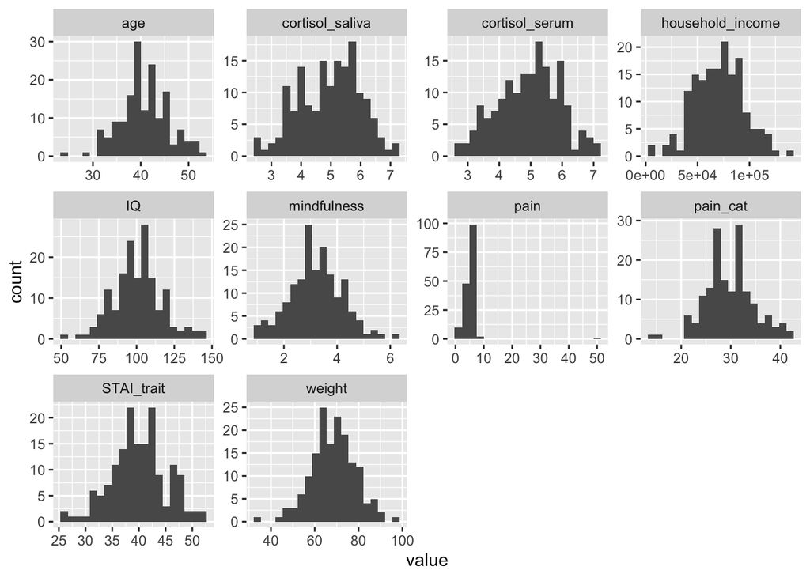

```r
# Histograms of the numeric variables
data_pain %>%
  select(where(is.numeric)) %>%
  pivot_longer(everything()) %>%
  ggplot(aes(x = value)) +
  geom_histogram(bins = 20) +
  facet_wrap(~ name, scales = "free")
```

#### Correct coding errors

If you find values in the dataset during the EDA, that are not correct based on the provided descriptions of the variables of the dataset please correct them here.

```r
# Fix coding errors
data_pain <- data_pain %>%
  mutate(
    # "woman" is the same as "female"
    sex = if_else(sex == "woman", "female", sex),
    sex = factor(sex),
    # values outside the allowed range are set to NA
    pain = if_else(pain > 10, NA_real_, pain), # pain must be 0-10
    mindfulness = if_else(mindfulness > 6, NA_real_, mindfulness)
  )

# Check the result
count(data_pain, sex)
```

```
## # A tibble: 2 × 2
##   sex        n
##   <fct>  <int>
## 1 female    84
## 2 male      76
```

```r
summary(data_pain)
```

```
##          ID           pain           sex          age          STAI_trait
##  Length   :160   Min.   :1.000   female:84   Min.   :24.00   Min.   :26.00
##  N.unique :160   1st Qu.:4.000   male  :76   1st Qu.:38.00   1st Qu.:37.00
##  N.blank  :  0   Median :5.000               Median :41.00   Median :40.00
##  Min.nchar:  4   Mean   :4.912               Mean   :40.74   Mean   :40.09
##  Max.nchar:  6   3rd Qu.:6.000               3rd Qu.:44.00   3rd Qu.:43.00
##                  Max.   :8.000               Max.   :53.00   Max.   :52.00
##                  NAs    :1
##     pain_cat     cortisol_serum  cortisol_saliva  mindfulness
##  Min.   :14.00   Min.   :2.700   Min.   :2.530   Min.   :1.000
##  1st Qu.:27.00   1st Qu.:4.268   1st Qu.:4.120   1st Qu.:2.590
##  Median :30.00   Median :4.995   Median :5.035   Median :3.110
##  Mean   :29.88   Mean   :4.941   Mean   :4.952   Mean   :3.186
##  3rd Qu.:32.25   3rd Qu.:5.633   3rd Qu.:5.753   3rd Qu.:3.830
##  Max.   :42.00   Max.   :7.110   Max.   :7.190   Max.   :5.630
##                                                  NAs    :1
##      weight            IQ         household_income
##  Min.   :33.80   Min.   : 52.00   Min.   :  5548
##  1st Qu.:62.15   1st Qu.: 91.75   1st Qu.: 53489
##  Median :68.77   Median :101.00   Median : 72149
##  Mean   :68.57   Mean   :100.74   Mean   : 70426
##  3rd Qu.:74.65   3rd Qu.:109.00   3rd Qu.: 87734
##  Max.   :97.13   Max.   :144.00   Max.   :139268
##
```

```r
# Remove rows with missing values in the model variables
data_pain <- data_pain %>%
  drop_na(pain, sex, age, STAI_trait, pain_cat, mindfulness,
          cortisol_serum, cortisol_saliva)

# Check: should be 158 rows
nrow(data_pain)
```

```
## [1] 158
```

I found three coding errors: one “woman” value was recoded to “female”, and two impossible values (pain = 50, mindfulness = 6.22) were set to missing. These two rows were excluded from the analysis, leaving 158 participants.

### Model diagnostics

#### Build the more complex model

In order to test the more complex model for outliers and to test the assumptions first build the model.

```r
mod_complex <- lm(pain ~ age + sex + STAI_trait + pain_cat + mindfulness +
                    cortisol_serum + cortisol_saliva, data = data_pain)
```

#### Checking for influential outliers

Check for outlier values in the model.

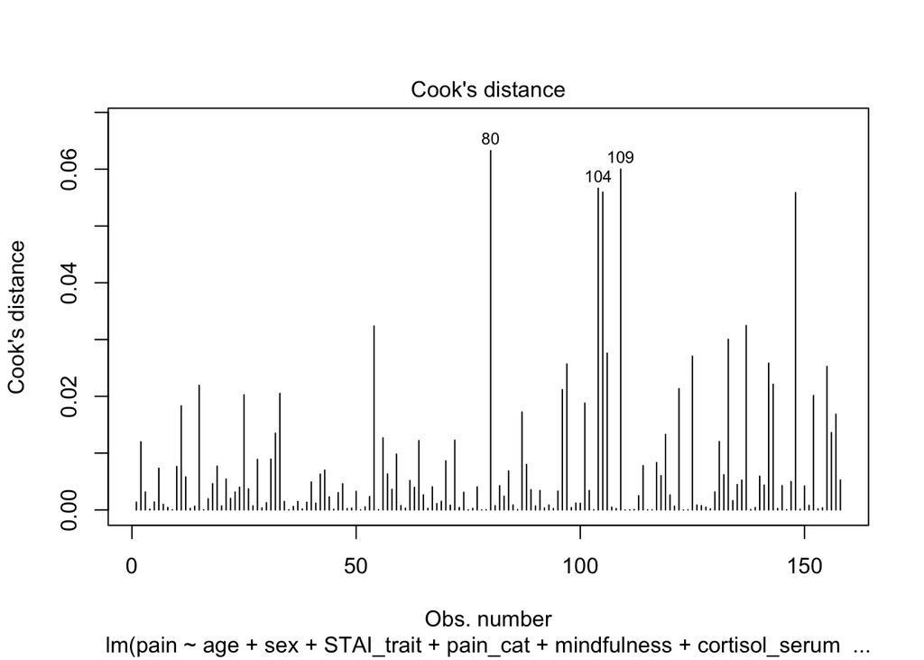

```r
# Cook's distance for each case
plot(mod_complex, which = 4)
```

```r
# Cases above the 4/n rule of thumb
cooks <- cooks.distance(mod_complex)
which(cooks > 4 / nrow(data_pain))
```

```
##  54  80  97 104 105 106 109 125 133 137 142 148
##  54  80  97 104 105 106 109 125 133 137 142 148
```

```r
max(cooks)
```

```
## [1] 0.06326933
```

Twelve cases exceeded the 4/n Cook’s distance cut-off (0.025), but the largest value was only 0.063, far below 1. No case was clearly influential, so all cases were kept.

#### Checking assumptions

Check the normality assumption.

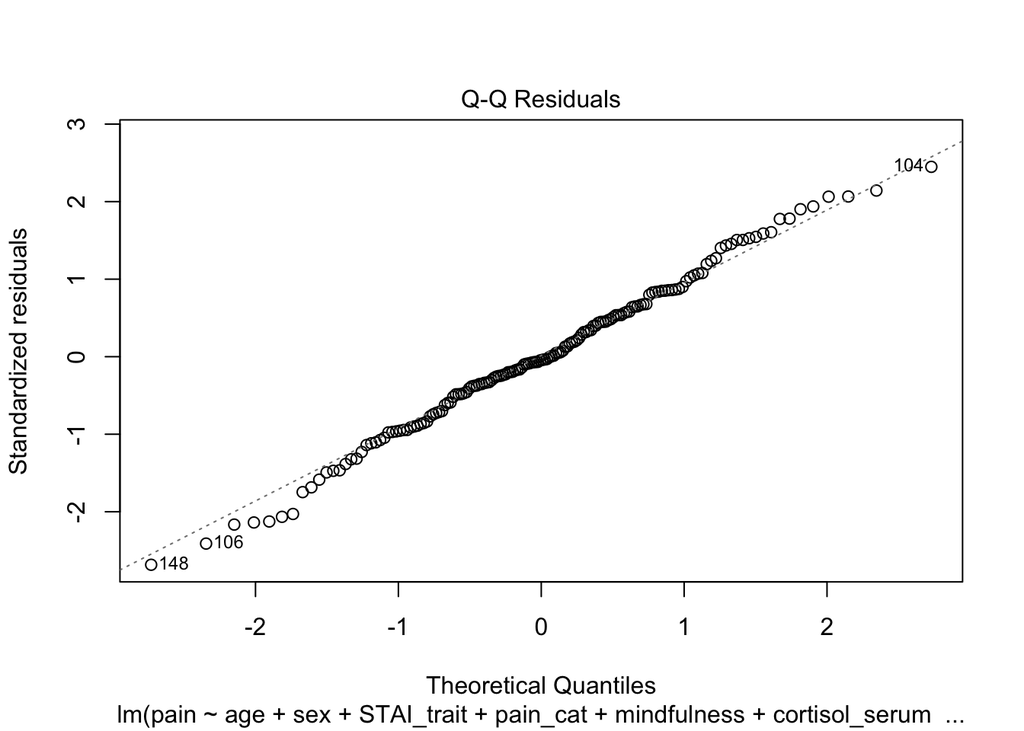

```r
# Normality
plot(mod_complex, which = 2)
```

```r
shapiro.test(residuals(mod_complex))
```

```
##
##  Shapiro-Wilk normality test
##
## data:  residuals(mod_complex)
## W = 0.99422, p-value = 0.788
```

The residuals were approximately normal (Shapiro-Wilk W = 0.994, p = 0.788). Check the linearity assumption.

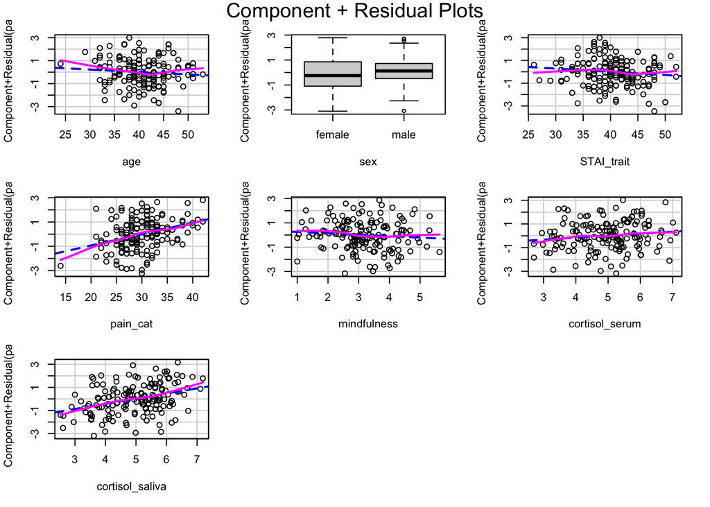

```r
# Linearity
car::crPlots(mod_complex)
```

The smooth lines on the component + residual plots were close to the linear fit, so linearity was acceptable. Check the homoscedasticty assumption (homogeneity of variance).

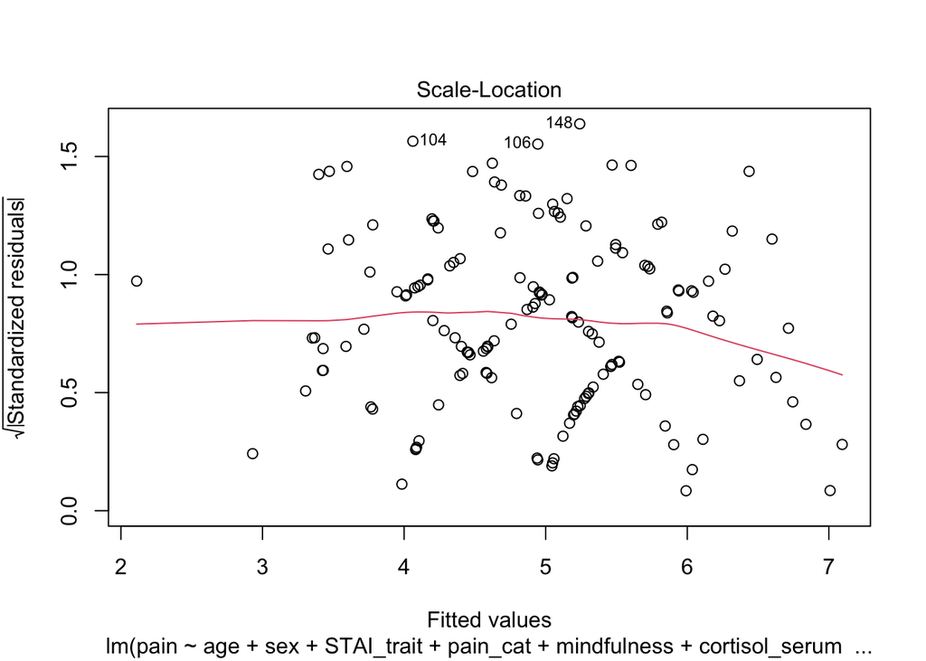

```r
# Homoscedasticity
plot(mod_complex, which = 3)
```

```r
lmtest::bptest(mod_complex)
```

```
##
##  studentized Breusch-Pagan test
##
## data:  mod_complex
## BP = 6.7628, df = 7, p-value = 0.454
```

The Breusch-Pagan test wasn’t significant (BP = 6.76, df = 7, p = 0.454) - the variance was constant. Check the multicollinearity assumption.

Some info about VIF: https://statisticalhorizons.com/multicollinearity http://blog.minitab.com/blog/understanding-statistics/handling-multicollinearity-in-regression-analysis

```r
# Multicollinearity
car::vif(mod_complex)
```

```
##             age             sex      STAI_trait        pain_cat     mindfulness
##        1.537752        1.134642        2.056568        1.836336        1.466876
##  cortisol_serum cortisol_saliva
##        6.020413        6.594781
```

```r
cor(data_pain$cortisol_serum, data_pain$cortisol_saliva)
```

```
## [1] 0.9078928
```

Serum and saliva cortisol were highly correlated (r = 0.91); their VIF values were above 5 (6.02 and 6.59). All other VIF value were below 2.1.

### Making decision based on model diagnostics

If based on the assumption tests you decide to drop a predictor variable you should do that here. Create your updated model.

```r
# Predictor with the high VIF (probably cortisol_saliva)
mod_final <- lm(pain ~ age + sex + STAI_trait + pain_cat + mindfulness +
                  cortisol_serum, data = data_pain)
```

Because of the multicollinearity, and because serum cortisol is considered the more reliable stress measure, I dropped salivary cortisol from the model. I then re-ran all checks on the updated model.

#### Checking outliers of the updated model

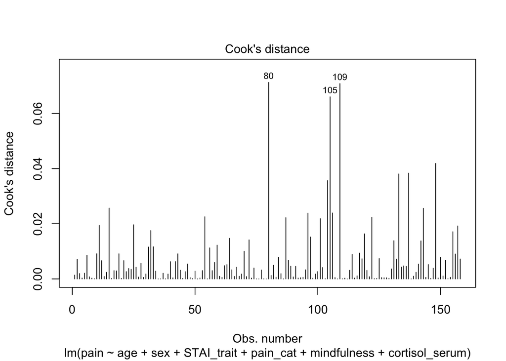

```r
# Run all checks on the updated model again
# Cook's distance of the updated model
plot(mod_final, which = 4)
```

```r
max(cooks.distance(mod_final))
```

```
## [1] 0.07126412
```

Cook’s distance was checked again on the updated model. The largest value was 0.071, far below 1, so no case was influential and all cases were kept.

#### Checking assumptions of the updated model

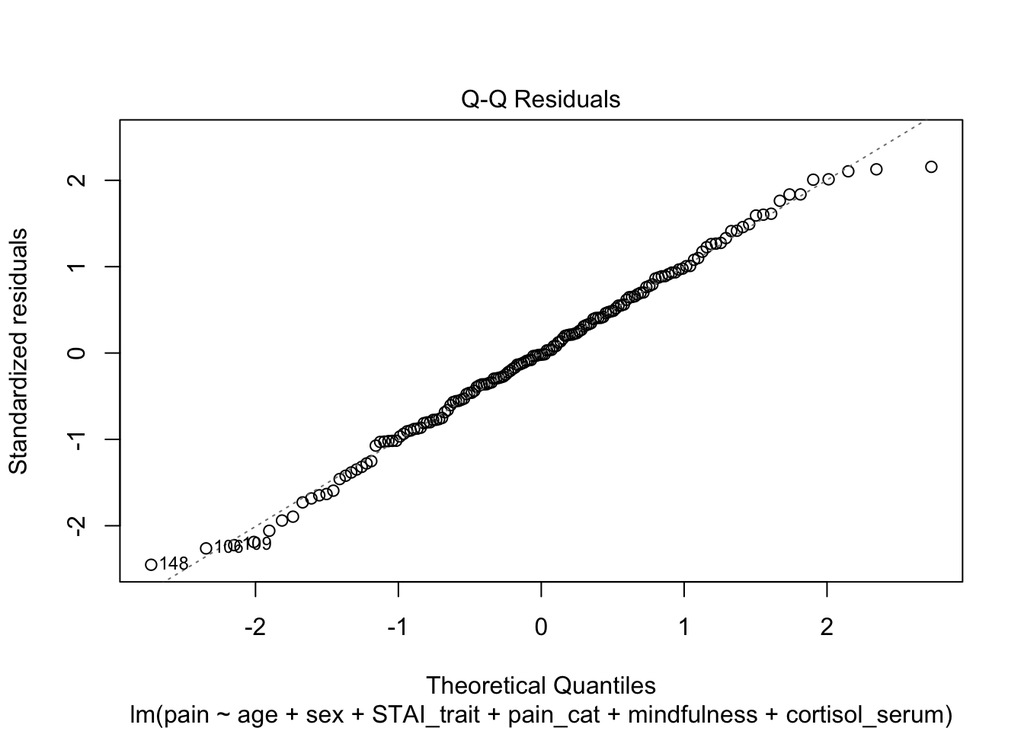

```r
# Normality
plot(mod_final, which = 2)
```

```r
shapiro.test(residuals(mod_final))
```

```
##
##  Shapiro-Wilk normality test
##
## data:  residuals(mod_final)
## W = 0.99275, p-value = 0.6118
```

The residuals of the updated model were approximately normal (Shapiro-Wilk W = 0.993, p = 0.612).

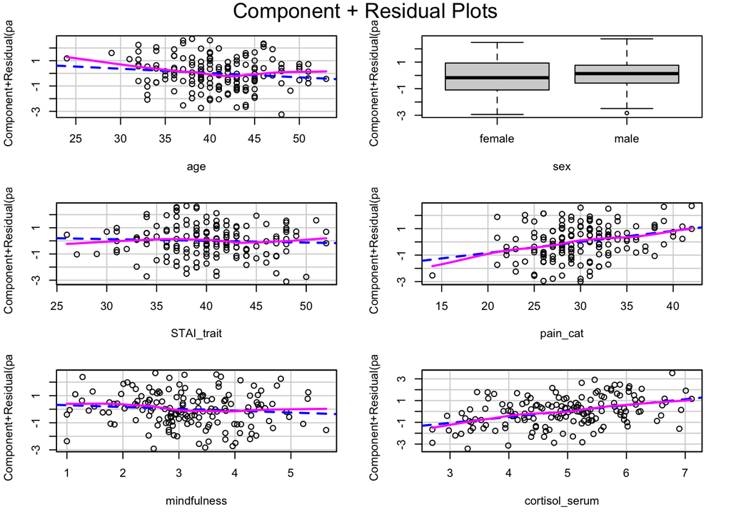

```r
# Linearity
car::crPlots(mod_final)
```

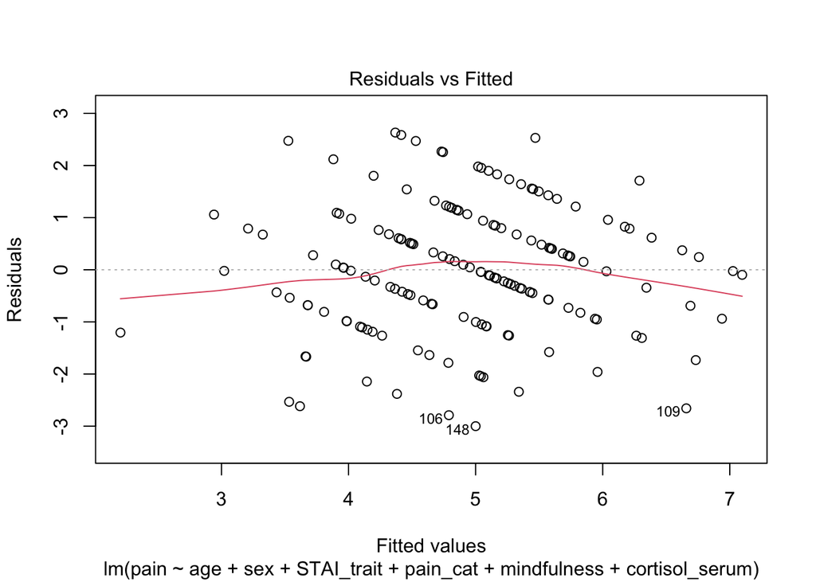

```r
plot(mod_final, which = 1)
```

The smooth lines on the component + residual plots were close to the linear fit, so linearity was acceptable.

Check the homoscedasticty assumption (homogeneity of variance).

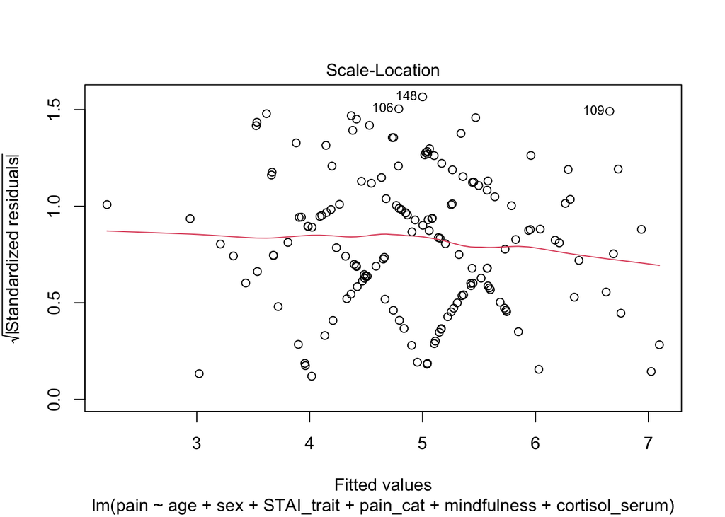

```r
# Homoscedasticity
plot(mod_final, which = 3)
```

```r
lmtest::bptest(mod_final)
```

```
##
##  studentized Breusch-Pagan test
##
## data:  mod_final
## BP = 7.0648, df = 6, p-value = 0.3149
```

The Breusch-Pagan test was not significant (BP = 7.06, df = 6, p = 0.315), so the variance was constant.

Check the multicollinearity assumption.

Some info about VIF: https://statisticalhorizons.com/multicollinearity http://blog.minitab.com/blog/understanding-statistics/handling-multicollinearity-in-regression-analysis

```r
# Multicollinearity
car::vif(mod_final)
```

```
##            age            sex     STAI_trait       pain_cat    mindfulness
##       1.407823       1.134247       1.873106       1.761359       1.456747
## cortisol_serum
##       1.533348
```

```r
cor(data_pain$cortisol_serum, data_pain$cortisol_saliva) # Correlation of the two cortisol measures (just for reference)
```

```
## [1] 0.9078928
```

All VIF values were below 2 (highest: 1.87 for STAI_trait), so multicollinearity was no longer a problem.

## Model comparison

Create the simple model and get the results of the model that needs to be reported based on the What to report section.

```r
# Simple model: age and sex only
mod_simple <- lm(pain ~ age + sex, data = data_pain)

# Model test statistics
glance(mod_simple) %>%
  select(adj.r.squared, statistic, df, df.residual, p.value, AIC) %>%
  mutate(
    p.value = ifelse(p.value < 0.001, "< .001", sprintf("%.3f", p.value)),
    across(where(is.numeric), ~ round(., 3))
  ) %>%
  knitr::kable(caption = "Model fit statistics for the simpler model")
```

Model fit statistics for the simpler model

| adj.r.squared | statistic | df | df.residual | p.value | AIC |
| --- | --- | --- | --- | --- | --- |
| 0.069 | 6.777 | 2 | 155 | 0.002 | 572.477 |

```r
# Coefficients table
tidy(mod_simple, conf.int = TRUE) %>%
  mutate(beta = lm.beta(mod_simple)$standardized.coefficients) %>%
  select(Predictor = term, B = estimate, `95% CI Lower` = conf.low,
         `95% CI Upper` = conf.high, Beta = beta, p = p.value) %>%
  mutate(
    p = ifelse(p < 0.001, "< .001", sprintf("%.3f", p)),
    across(where(is.numeric), ~ round(., 3))
  ) %>%
  knitr::kable(caption = "Regression coefficients for the simpler model")
```

Regression coefficients for the simpler model

| Predictor | B | 95% CI Lower | 95% CI Upper | Beta | p |
| --- | --- | --- | --- | --- | --- |
| (Intercept) | 8.306 | 6.426 | 10.185 | NA | < .001 |
| age | -0.084 | -0.130 | -0.039 | -0.281 | < .001 |
| sexmale | 0.131 | -0.328 | 0.590 | 0.044 | 0.573 |

The simpler model (age and sex) explained a small part of the variance in pain (adj. R² = 0.069, F(2, 155) = 6.78, p = 0.002). Age was a significant negative predictor (B = -0.084, 95% CI [-0.13, -0.039], β = -0.281, p < 0.001), sex was not (B = 0.131, 95% CI [-0.328, 0.59], β = 0.044, p = 0.573). Create the more complex model based on the results of the model diagnostics. Also, get the results that needs to be reported based on the What to report section.

```r
# Final model test statistics
glance(mod_final) %>%
  select(adj.r.squared, statistic, df, df.residual, p.value, AIC) %>%
  mutate(
    p.value = ifelse(p.value < 0.001, "< .001", sprintf("%.3f", p.value)),
    across(where(is.numeric), ~ round(., 3))
  ) %>%
  knitr::kable(caption = "Model fit statistics for the final complex model")
```

Model fit statistics for the final complex model

| adj.r.squared | statistic | df | df.residual | p.value | AIC |
| --- | --- | --- | --- | --- | --- |
| 0.312 | 12.854 | 6 | 151 | < .001 | 528.529 |

```r
# Final model coefficients table
tidy(mod_final, conf.int = TRUE) %>%
  mutate(beta = lm.beta(mod_final)$standardized.coefficients) %>%
  select(Predictor = term, B = estimate, `95% CI Lower` = conf.low,
         `95% CI Upper` = conf.high, Beta = beta, p = p.value) %>%
  mutate(
    p = ifelse(p < 0.001, "< .001", sprintf("%.3f", p)),
    across(where(is.numeric), ~ round(., 3))
  ) %>%
  knitr::kable(caption = "Regression coefficients for the final complex model")
```

Regression coefficients for the final complex model

| Predictor | B | 95% CI Lower | 95% CI Upper | Beta | p |
| --- | --- | --- | --- | --- | --- |
| (Intercept) | 1.945 | -1.418 | 5.308 | NA | 0.255 |
| age | -0.034 | -0.081 | 0.013 | -0.113 | 0.151 |
| sexmale | 0.316 | -0.104 | 0.736 | 0.105 | 0.140 |
| STAI_trait | -0.013 | -0.067 | 0.040 | -0.044 | 0.626 |
| pain_cat | 0.083 | 0.027 | 0.140 | 0.257 | 0.004 |
| mindfulness | -0.136 | -0.386 | 0.114 | -0.086 | 0.284 |
| cortisol_serum | 0.543 | 0.297 | 0.790 | 0.357 | < .001 |

```r
# Coefficients for the regression equation
round(coef(mod_final), 3)
```

```
##    (Intercept)            age        sexmale     STAI_trait       pain_cat
##          1.945         -0.034          0.316         -0.013          0.083
##    mindfulness cortisol_serum
##         -0.136          0.543
```

The more complex model explained substantially more variance (adj. R² = 0.312, F(6, 151) = 12.9, p < 0.001). Serum cortisol (B = 0.543, β = 0.357, p < 0.001) and pain catastrophizing (B = 0.083, β = 0.257, p = 0.004) were significant predictors.

The regression equation of the model:

Pain = 1.945 - 0.034 * age + 0.316 * sex(male) - 0.013 * STAI_trait + 0.083 * pain_cat - 0.136 * mindfulness + 0.543 * cortisol_serum

Compare the two models.

```r
# AIC of both models (lower is better)
AIC(mod_simple, mod_final)
```

```
##            df      AIC
## mod_simple  4 572.4769
## mod_final   8 528.5295
```

```r
# F test comparing the two nested models
anova(mod_simple, mod_final)
```

```
## Analysis of Variance Table
##
## Model 1: pain ~ age + sex
## Model 2: pain ~ age + sex + STAI_trait + pain_cat + mindfulness + cortisol_serum
##   Res.Df    RSS Df Sum of Sq      F    Pr(>F)
## 1    155 329.43
## 2    151 237.12  4    92.306 14.695 3.673e-10 ***
## ---
## Signif. codes:  0 '***' 0.001 '**' 0.01 '*' 0.05 '.' 0.1 ' ' 1
```

The AIC was lower for the more complex model (528.5 vs. 572.5), and the model comparison test showed a significantly better fit (F(4, 151) = 14.70, p < 0.001).

## Discussion

Adding the psychological and hormonal variables clearly improved our understanding of postoperative pain. The explained variance increased from about 7% to about 31% (adjusted R²), the AIC dropped by 44 points, and the F test was significant. Within the more complex model, serum cortisol and pain catastrophizing were the only significant predictors: higher levels of both were associated with higher pain. Trait anxiety and mindfulness did not add unique information once the other variables were included. Age was a significant predictor in the simpler model but not in the complex one, which suggests that its effect overlaps with the added variables. A limitation is that the data are simulated and cross-sectional, so the results show associations, not causation. Also, salivary cortisol was dropped because of multicollinearity, so its separate contribution could not be assessed.